# R Notebook

Load libraries

```r
library(tidyverse)
library(caret)
library(rpart)
library(knitr) #Dynamic Report Generator including use of LateX, HTML
library(gridExtra)
library(corrplot)
library(Boruta) #Feature selection
library(randomForest) #Random forest
library(ggRandomForests) #variable importance random forest
library(DMwR) #BINARY CLASSIFICATION
```

Import the data

```r
hr_data  <- HR_Employee_Attrition_data
str(hr_data)
```

```
Classes ‘tbl_df’, ‘tbl’ and 'data.frame':   1470 obs. of  35 variables:
 $ Employee Count            : num  1 1 1 1 1 1 1 1 1 1 ...
 $ Employee ID               : num  1 2 4 5 7 8 10 11 12 13 ...
 $ Department                : chr  "Sales" "Research & Development" "Research & Development" "Research & Development" ...
 $ Job Role                  : chr  "Sales Executive" "Research Scientist" "Laboratory Technician" "Research Scientist" ...
 $ Attrition (Yes/No)        : chr  "Yes" "No" "Yes" "No" ...
 $ Gender                    : chr  "Female" "Male" "Male" "Female" ...
 $ Age                       : num  41 49 37 33 27 32 59 30 38 36 ...
 $ Over 18                   : chr  "Y" "Y" "Y" "Y" ...
 $ Marital Status            : chr  "Single" "Married" "Single" "Married" ...
 $ Education                 : chr  "College" "Below College" "College" "Master" ...
 $ Education Field           : chr  "Life Sciences" "Life Sciences" "Other" "Life Sciences" ...
 $ Business Travel           : chr  "Travel_Rarely" "Travel_Frequently" "Travel_Rarely" "Travel_Frequently" ...
 $ Distance From Home (kms)  : num  1 8 2 3 2 2 3 24 23 27 ...
 $ Job Involvement           : chr  "High" "Medium" "Medium" "High" ...
```

[output cut: 21 more lines]

Looking at the dataset, there are too many variables and we might not need all. For example. We will exclude “Over 18”, “Employee Count”, “Standard Hours”. Those variables are not informative and there is not variance in these variables

```r
hr_data = hr_data[,!(names(hr_data) %in% c('Over 18','Employee Count','Standard Hours','Employee ID'))]
str(hr_data)
```

```
Classes ‘tbl_df’, ‘tbl’ and 'data.frame':   1470 obs. of  31 variables:
 $ Department                : chr  "Sales" "Research & Development" "Research & Development" "Research & Development" ...
 $ Job Role                  : chr  "Sales Executive" "Research Scientist" "Laboratory Technician" "Research Scientist" ...
 $ Attrition (Yes/No)        : chr  "Yes" "No" "Yes" "No" ...
 $ Gender                    : chr  "Female" "Male" "Male" "Female" ...
 $ Age                       : num  41 49 37 33 27 32 59 30 38 36 ...
 $ Marital Status            : chr  "Single" "Married" "Single" "Married" ...
 $ Education                 : chr  "College" "Below College" "College" "Master" ...
 $ Education Field           : chr  "Life Sciences" "Life Sciences" "Other" "Life Sciences" ...
 $ Business Travel           : chr  "Travel_Rarely" "Travel_Frequently" "Travel_Rarely" "Travel_Frequently" ...
 $ Distance From Home (kms)  : num  1 8 2 3 2 2 3 24 23 27 ...
 $ Job Involvement           : chr  "High" "Medium" "Medium" "High" ...
 $ Job Level                 : num  2 2 1 1 1 1 1 1 3 2 ...
 $ Job Satisfaction          : chr  "Very High" "Medium" "High" "High" ...
 $ Hourly Rate (USD)         : num  94 61 92 56 40 79 81 67 44 94 ...
```

[output cut: 17 more lines]

Proceeding for Data Visualizing and Feature Extraction . Visualizing the different features will help to determine the features that might be important for our prediction.

Checking the attirition percentage of the IBM organisation

```r
hr_data$Attrition <- hr_data$`Attrition (Yes/No)`
(prop.table(table(hr_data$Attrition))*100)
```

```
      No      Yes
83.87755 16.12245
```

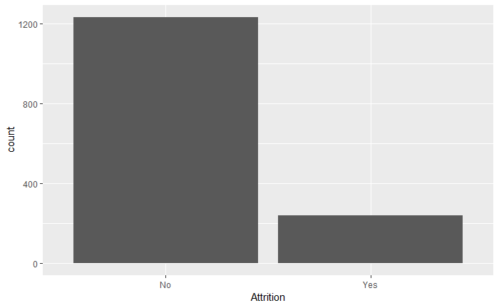

```r
ggplot(hr_data, aes(Attrition)) + geom_bar()
```

In 1470 obervations of 31 variables, we see that about 84% of the population stayed at the organization and about 16% of the population left

# Deparment and Attrition

Visualizing the Department of the employee ad the Relationship to attrition

```r
table(hr_data$Department)
```

```
       Human Resources Research & Development                  Sales
                    63                    961                    446
```

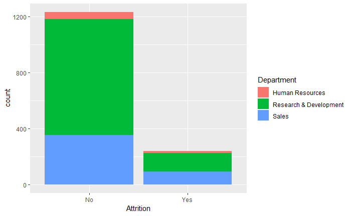

```r
ggplot(hr_data, aes(Attrition, fill = Department)) + geom_bar()
```

```r
# Most of the employees are from the Research and Development department
```

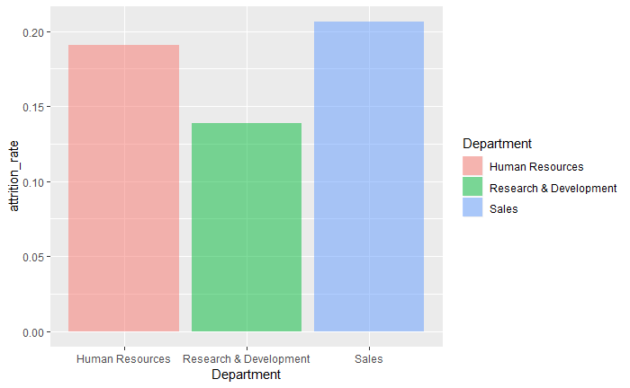

```r
Dep_att <- hr_data %>%group_by(Department)%>%summarize(attrition_rate=mean(Attrition=="Yes"))%>% ggplot(aes(x=Department,y=attrition_rate,fill=Department)) + geom_bar(stat='identity', alpha = 0.5)
Dep_att
```

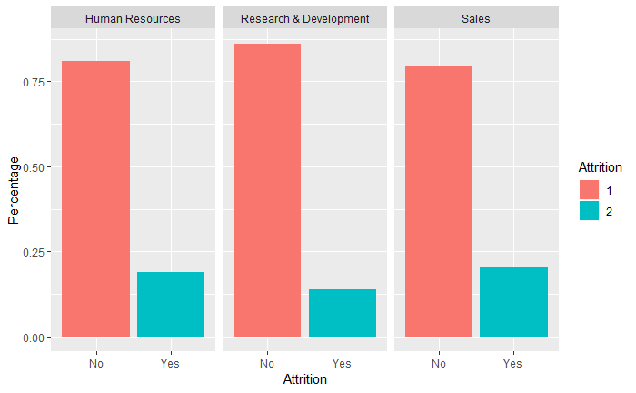

```r
ggplot(hr_data, aes(Attrition, group=Department)) +
  geom_bar(aes(y = ..prop.., fill= factor(..x..))) +
  labs(y="Percentage", fill = "Attrition") +
  facet_grid(~Department)
```

It is evident that from the visualized bar chart that Sales has a higher attriton rate.

# Marital status and Attrition

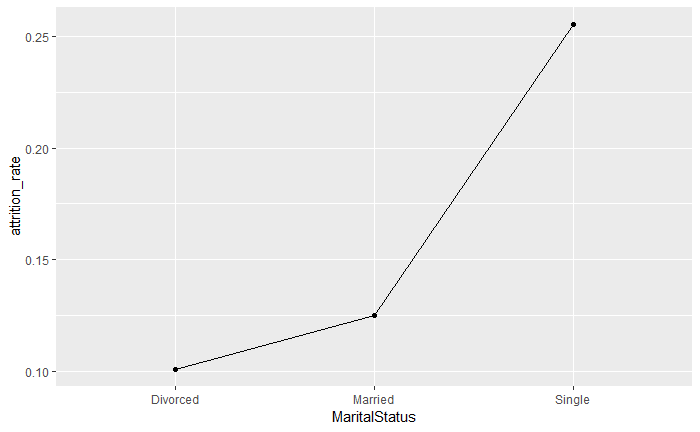

```r
hr_data$MaritalStatus = hr_data$`Marital Status`
mar_status <-hr_data %>% group_by(MaritalStatus)%>%
  summarize(attrition_rate=mean(Attrition=="Yes"))%>%
  ggplot(aes(x=MaritalStatus,y=attrition_rate,group=2)) + geom_line(stat='identity') +geom_point()
mar_status
```

## Attrition and Business Travel

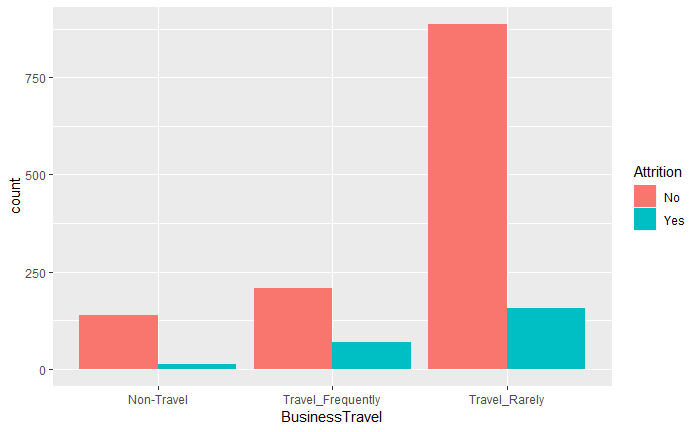

```r
hr_data$BusinessTravel <- hr_data$`Business Travel`
ggplot(hr_data, aes(BusinessTravel, fill = Attrition)) + geom_bar(stat= "count", position =  position_dodge())
```

## Attrition and Gender

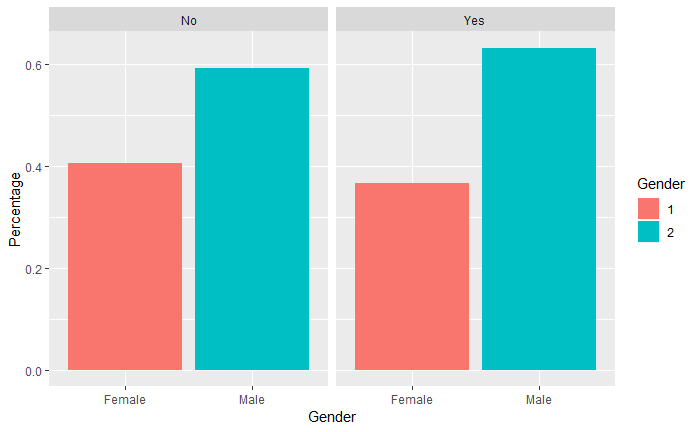

```r
ggplot(hr_data, aes(Gender, group= Attrition)) +
  geom_bar(aes(y = ..prop.., fill= factor(..x..)), stat = "count") +
  labs(y="Percentage", fill = "Gender") +
  facet_grid(~Attrition)
```

## Attrition and Age

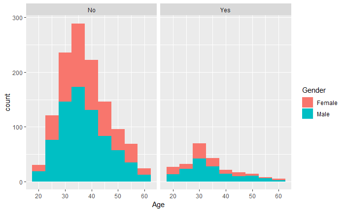

```r
ggplot(hr_data, aes(Age, fill = Gender)) +
  geom_histogram(binwidth = 5) +
  facet_grid(~Attrition)
```

It is seen from the data visualization that the median age of the organization between 30-40 years. Also a the people who leave the organization are between 30-40 years old, likewise a significant number of people who doesnt leave the organization.

# We will do a feature extraction of the age seperating the older people from the younger people.

## Job Role and Attrition

We know that work and stress levels might make an employee leave an organization, and that might depend on the job role. We want to visualize the job role and attrition to know the relationship between job roles and attrition.

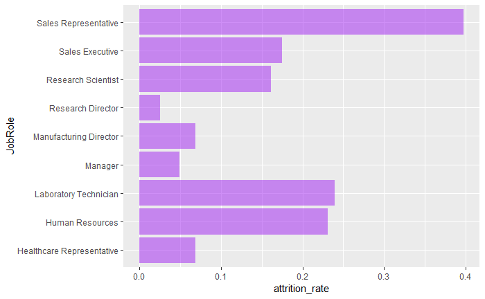

```r
hr_data$JobRole <- hr_data$`Job Role`
job_att <-hr_data %>%
  group_by(JobRole)%>%
  summarize(attrition_rate=mean(Attrition=="Yes"))%>%
  ggplot(aes(x=JobRole,y=attrition_rate)) + geom_bar(stat='identity',alpha=0.5,fill="purple") +
  coord_flip()
job_att
```

We see that the sales representatives have more attrition rate than any other department. The Stress level of the sales representative might make it a more likely factor of an employee leaving the organization. It also seems that the managers and leaders have a lower attrition rate.

# We will extract features of Mangers and staff of the company

## Attrition and Distance from Home

The likelihood that an employee will leave an organization might likely depend on the distance to the office. If the distance is too far, the employee might be looking to leave. We wil visuaize the relationship between distance to home and attrition

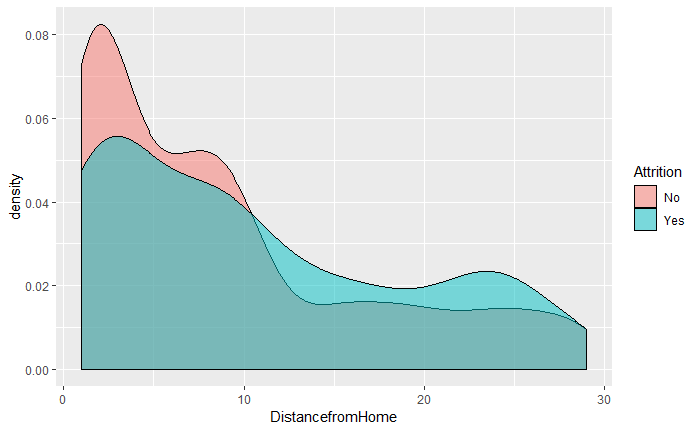

```r
hr_data$DistancefromHome <- hr_data$`Distance From Home (kms)`
ggplot(hr_data,aes(DistancefromHome,fill=Attrition)) +
  geom_density(alpha=0.5)
```

```r
NA
```

There doesnt a great deal in people staying far away from the office. There are a number of people staying closer to the office, the attrition rate are quite lower for those who stay within 10km away from the office. For those who stay farther away from the office, the attriton rate is quite higher.

## Attrition and Payrates

Visualzing the relationship between attrition and the different payrates using a boxplot.

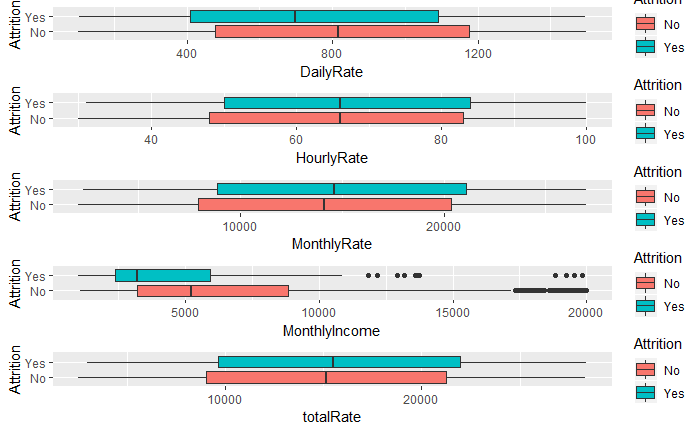

```r
hr_data$DailyRate <- hr_data$`Daily Rate (USD)`
hr_data$HourlyRate <- hr_data$`Hourly Rate (USD)`
hr_data$MonthlyRate <- hr_data$`Monthly Rate (USD)`
hr_data$MonthlyIncome <- hr_data$`Monthly Income (USD)`
  dr <- ggplot(hr_data,aes(Attrition,DailyRate, fill = Attrition)) + geom_boxplot() + coord_flip()
  hr <- ggplot(hr_data,aes(Attrition,HourlyRate, fill = Attrition)) + geom_boxplot() + coord_flip()
  mr <- ggplot(hr_data,aes(Attrition,MonthlyRate, fill = Attrition)) + geom_boxplot() + coord_flip()
  mi <- ggplot(hr_data,aes(Attrition,MonthlyIncome, fill = Attrition)) + geom_boxplot() + coord_flip()
  #feature extraction of rates
  hr_data$totalRate <- hr_data$DailyRate + hr_data$HourlyRate + hr_data$MonthlyRate
  tr  <- ggplot(hr_data,aes(Attrition,totalRate, fill = Attrition)) + geom_boxplot() + coord_flip()

  grid.arrange(dr,hr,mr,mi,tr,nrow = 5)
```

```r
NA
```

# Monthly income and Job roles

Sales representatives employees tend to leave the organization most. We want to visualize the relationship between the monthly income and the job roles(Which Job is least paying?)

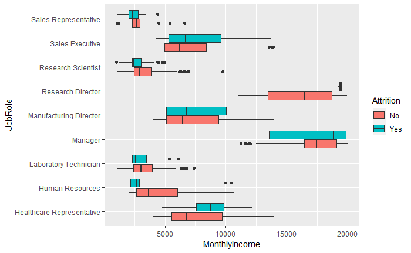

```r
ggplot(hr_data, aes(JobRole,MonthlyIncome, fill= Attrition)) + geom_boxplot() +
  coord_flip()
```

```r
NA
```

## Correlation analysis

Visualizing the correlation between numerical variables, and checking for colinearity.

```r
str(hr_data)
```

```
Classes ‘tbl_df’, ‘tbl’ and 'data.frame':   1470 obs. of  41 variables:
 $ Department                : chr  "Sales" "Research & Development" "Research & Development" "Research & Development" ...
 $ Job Role                  : chr  "Sales Executive" "Research Scientist" "Laboratory Technician" "Research Scientist" ...
 $ Attrition (Yes/No)        : chr  "Yes" "No" "Yes" "No" ...
 $ Gender                    : chr  "Female" "Male" "Male" "Female" ...
 $ Age                       : num  41 49 37 33 27 32 59 30 38 36 ...
 $ Marital Status            : chr  "Single" "Married" "Single" "Married" ...
 $ Education                 : chr  "College" "Below College" "College" "Master" ...
 $ Education Field           : chr  "Life Sciences" "Life Sciences" "Other" "Life Sciences" ...
 $ Business Travel           : chr  "Travel_Rarely" "Travel_Frequently" "Travel_Rarely" "Travel_Frequently" ...
 $ Distance From Home (kms)  : num  1 8 2 3 2 2 3 24 23 27 ...
 $ Job Involvement           : chr  "High" "Medium" "Medium" "High" ...
 $ Job Level                 : num  2 2 1 1 1 1 1 1 3 2 ...
 $ Job Satisfaction          : chr  "Very High" "Medium" "High" "High" ...
 $ Hourly Rate (USD)         : num  94 61 92 56 40 79 81 67 44 94 ...
```

[output cut: 27 more lines]

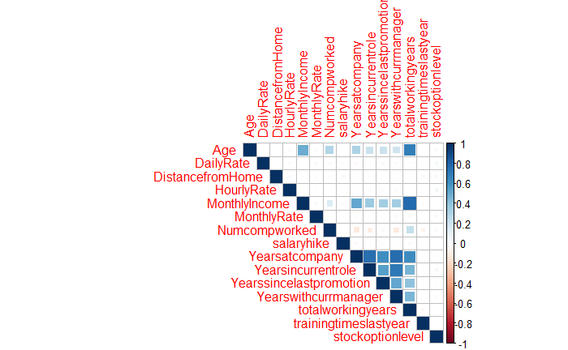

```r
hr_data$Numcompworked <- hr_data$`No. of Companies Worked`
hr_data$Yearsatcompany <- hr_data$`Years At Company`
hr_data$Yearsincurrentrole <- hr_data$`Years In Current Role`
hr_data$Yearswithcurrmanager <- hr_data$`Years With Curr Manager`
hr_data$Yearssincelastpromotion <- hr_data$`Years Since Last Promotion`
hr_data$totalworkingyears <- hr_data$`Total Working Years`
hr_data$trainingtimeslastyear <- hr_data$`Training Times Last Year`
hr_data$stockoptionlevel <- hr_data$`Stock Option Level`
hr_data$salaryhike <- hr_data$`Salary Hike (%)`
data_corr = hr_data %>%
  dplyr::select(Age,DailyRate,DistancefromHome,HourlyRate,MonthlyIncome,MonthlyRate, Numcompworked,salaryhike,Yearsatcompany,Yearsincurrentrole,Yearssincelastpromotion,Yearswithcurrmanager,totalworkingyears,trainingtimeslastyear,stockoptionlevel)
corrplot(cor(data_corr), method = "square", type="upper")
```

From the correlation plot, we observe correlated features. We will exclude the variables that are correlated from the model. (Colinearity). The correlated variables are: Age and total working years Total working years and monthly income Years with current manager and years at company Years with current current manager and years in current role

# The variables we will exclude are Years with current manager and total working years

## Attrition and Salary Hike

Visualizing salary hike and attrition

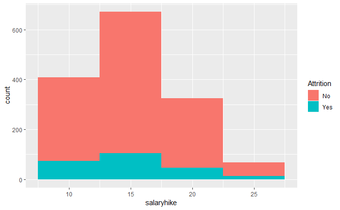

```r
ggplot(hr_data,aes(salaryhike, fill = Attrition)) + geom_histogram(binwidth =  5)
```

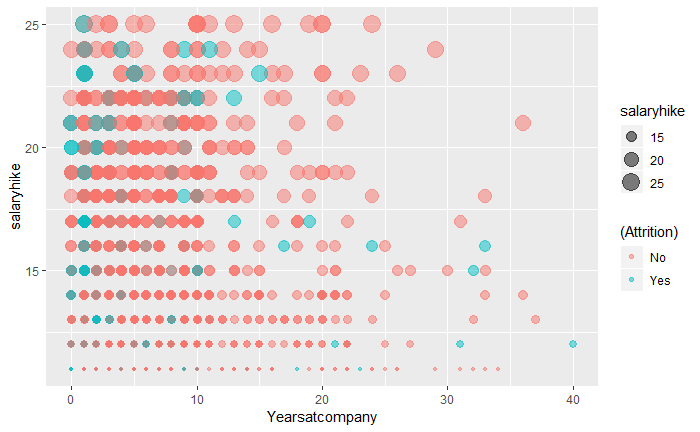

```r
#Salary Hike and Years at company
ggplot(hr_data,aes(Yearsatcompany,salaryhike,col=(Attrition),size = salaryhike)) +geom_point(alpha = 0.5)
```

```r
#Salary Hike and Years at experience
#ggplot(hr_data,aes(totalworkingyears,salaryhike,col=(Attrition),colour = salaryhike))+ geom_point(alpha = 0.5)
```

## Attrition and Education

Visualizing attrition rate and education levels and fields

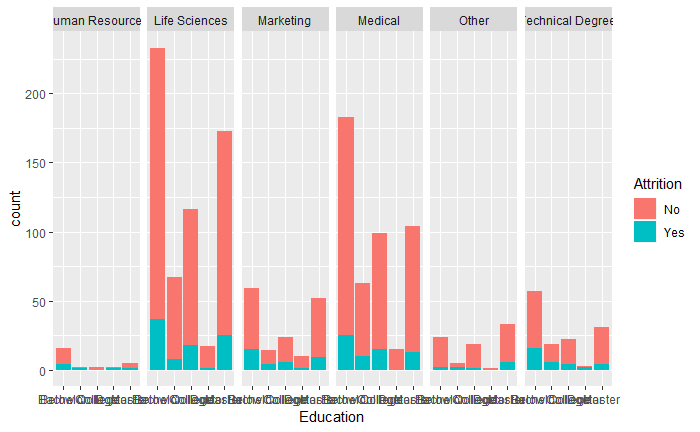

```r
hr_data$educationfield <- hr_data$`Education Field`
ggplot(hr_data,aes(Education, fill = Attrition)) +geom_bar() + facet_grid(~educationfield)
```

EMployees mith a life sciences and medical education level seems more populated in the organization. There also seems more people with a bachelor degree in the organization. However educational background might not be related to attrition levels

## Attrition and categorical variables.

# Attrition and JOb Satisfaction * Years with current manager

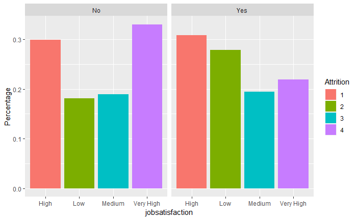

```r
hr_data$jobsatisfaction <- hr_data$`Job Satisfaction`
hr_data$jobinvolvement <- hr_data$`Job Involvement`
hr_data$relationshipsatisfaction <- hr_data$`Relationship Satisfaction`
hr_data$worklifebalance <- hr_data$`Work Life Balance`
hr_data$environmentsatisfaction <- hr_data$`Environment Satisfaction`
hr_data$overtime <- hr_data$`Over Time`
hr_data$performancerating <- hr_data$`Performance Rating`
ggplot(hr_data,aes(x=jobsatisfaction,group=Attrition))+
  geom_bar(stat="count",aes(y=..prop..,fill=factor(..x..))) +
  labs(y="Percentage", fill = "Attrition") +
  facet_wrap(~Attrition)
```

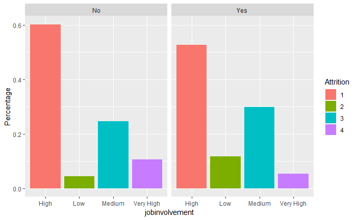

```r
ggplot(hr_data,aes(x=jobinvolvement,group=Attrition))+
  geom_bar(stat="count",aes(y=..prop..,fill=factor(..x..))) +
  labs(y="Percentage", fill = "Attrition") +
  facet_wrap(~Attrition)
```

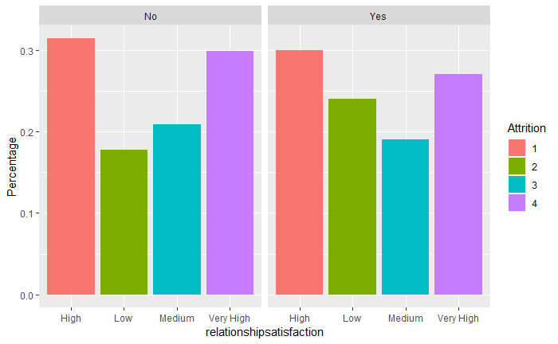

```r
ggplot(hr_data,aes(x=relationshipsatisfaction,group=Attrition))+
  geom_bar(stat="count",aes(y=..prop..,fill=factor(..x..)),position = position_dodge()) +
  labs(y="Percentage", fill = "Attrition") +
  facet_wrap(~Attrition)
```

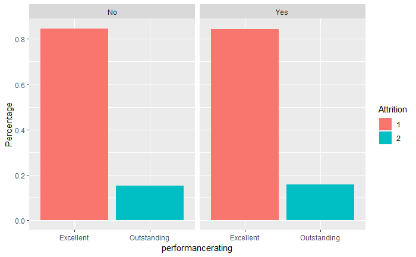

```r
ggplot(hr_data,aes(x=performancerating,group=Attrition))+
  geom_bar(stat="count",aes(y=..prop..,fill=factor(..x..))) +
  labs(y="Percentage", fill = "Attrition") +
  facet_wrap(~Attrition)
```

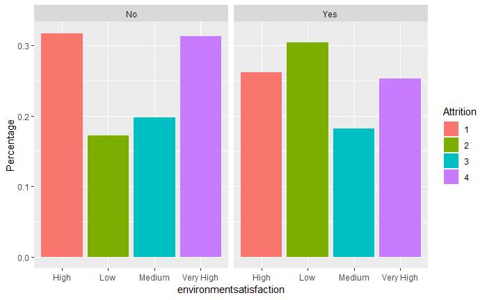

```r
ggplot(hr_data,aes(x=environmentsatisfaction,group=Attrition))+
  geom_bar(stat="count",aes(y=..prop..,fill=factor(..x..))) +
  labs(y="Percentage", fill = "Attrition") +
  facet_wrap(~Attrition)
```

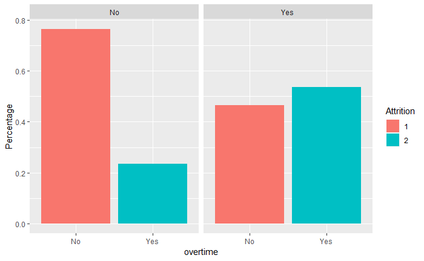

```r
ggplot(hr_data,aes(x=overtime,group=Attrition))+
  geom_bar(stat="count",aes(y=..prop..,fill=factor(..x..))) +
  labs(y="Percentage", fill = "Attrition") +
  facet_wrap(~Attrition)
```

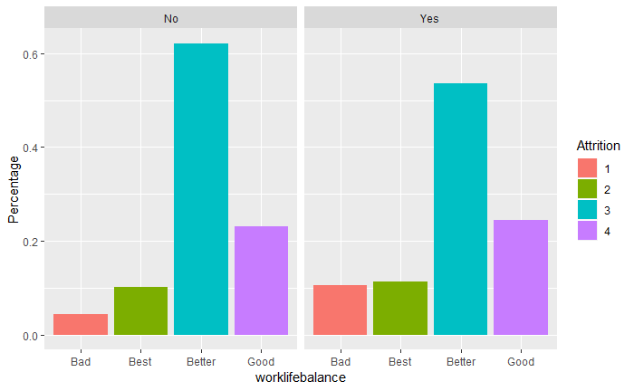

```r
ggplot(hr_data,aes(x=worklifebalance,group=Attrition))+
  geom_bar(stat="count",aes(y=..prop..,fill=factor(..x..))) +
  labs(y="Percentage", fill = "Attrition") +
  facet_wrap(~Attrition)
```

We observe that people with low job satisfaction have higher attrition rate. Also it appears that people with high job satisfication tend to leave the company, however in people who do not leave. those who have very high job satisfaction then to stay.

High relationship satisfaction have also reported staying as well as almost the same number of people have reported leaving

## Feature extraction

Feature engineering from the variables. For age, we want to divide the age into 3 groups.

```r
hr_data$AgeGroup <- as.factor(ifelse(hr_data$Age <= 25, "Young", ifelse(hr_data$Age<=50, "Middle Age", "Adult")))
table(hr_data$AgeGroup,hr_data$Attrition)
```

```
               No  Yes
  Adult       125   18
  Middle Age 1029  175
  Young        79   44
```

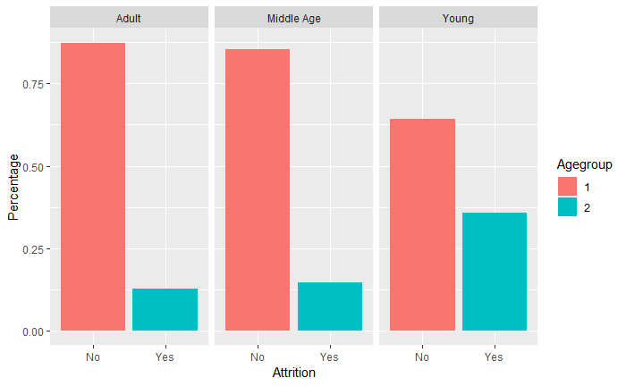

```r
ggplot(hr_data,aes(x=Attrition,group=AgeGroup))+
  geom_bar(stat="count",aes(y=..prop..,fill=factor(..x..))) +
  labs(y="Percentage", fill = "Agegroup") +
  facet_wrap(~AgeGroup)
```

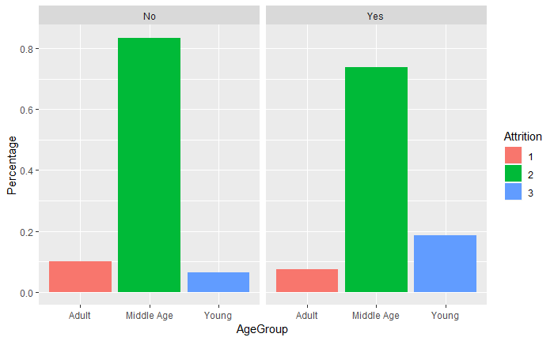

```r
ggplot(hr_data,aes(x=AgeGroup,group=Attrition))+
  geom_bar(stat="count",aes(y=..prop..,fill=factor(..x..))) +
  labs(y="Percentage", fill = "Attrition") +
  facet_wrap(~Attrition)
```

We can conclude that majority of the employees in the organization are middle aged. Also young people below 25 years tend to leave more.

# Age group and work-life balance

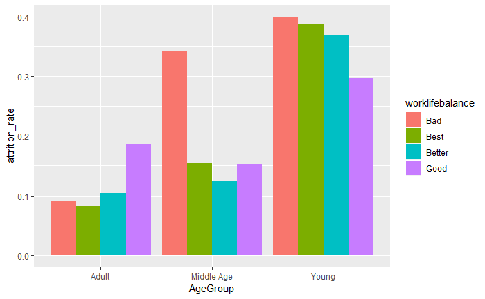

```r
age_work <- hr_data%>%group_by(AgeGroup,worklifebalance)%>%summarize(attrition_rate=mean(Attrition=="Yes")) %>%
ggplot(aes(x=AgeGroup,y=attrition_rate,fill=worklifebalance)) + geom_bar(stat="identity",position = position_dodge())
age_work
```

```r
#Agegroup and monthly income by (department,job class)
#
```

Adult have the lowest attrition rate in percentage and it appears they have the the lowest reported bad work-life balance. Young people have the highest reported bad work-life environment. Probably that is why they leave more. ##Total Satisfaction

```r
hr_data$environmentsatisfaction[hr_data$environmentsatisfaction=="Low"] <- 1
hr_data$environmentsatisfaction[hr_data$environmentsatisfaction=="Medium"] <- 2
hr_data$environmentsatisfaction[hr_data$environmentsatisfaction=="High"] <- 3
hr_data$environmentsatisfaction[hr_data$environmentsatisfaction=="Very High"] <- 4
str(hr_data$environmentsatisfaction)
```

```
 chr [1:1470] "2" "3" "4" "4" "1" "4" "3" "4" "4" "3" "1" "4" "1" "2" "3" "2" "1" ...
```

```r
hr_data$jobsatisfaction[hr_data$jobsatisfaction=="Low"] <- 1
hr_data$jobsatisfaction[hr_data$jobsatisfaction=="Medium"] <- 2
hr_data$jobsatisfaction[hr_data$jobsatisfaction=="High"] <- 3
hr_data$jobsatisfaction[hr_data$jobsatisfaction=="Very High"] <- 4
str(hr_data$jobsatisfaction)
```

```
 chr [1:1470] "4" "2" "3" "3" "2" "4" "1" "3" "3" "3" "2" "3" "3" "4" "3" "1" "2" ...
```

```r
hr_data$relationshipsatisfaction[hr_data$relationshipsatisfaction=="Low"] <- 1
hr_data$relationshipsatisfaction[hr_data$relationshipsatisfaction=="Medium"] <- 2
hr_data$relationshipsatisfaction[hr_data$relationshipsatisfaction=="High"] <- 3
hr_data$relationshipsatisfaction[hr_data$relationshipsatisfaction=="Very High"] <- 4
str(hr_data$relationshipsatisfaction)
```

```
 chr [1:1470] "1" "4" "2" "3" "4" "3" "1" "2" "2" "2" "3" "4" "4" "3" "2" "3" "4" ...
```

```r
hr_data$jobinvolvement[hr_data$jobinvolvement=="Low"] <- 1
hr_data$jobinvolvement[hr_data$jobinvolvement=="Medium"] <- 2
hr_data$jobinvolvement[hr_data$jobinvolvement=="High"] <- 3
hr_data$jobinvolvement[hr_data$jobinvolvement=="Very High"] <- 4
str(hr_data$jobinvolvement)
```

```
 chr [1:1470] "3" "2" "2" "3" "3" "3" "4" "3" "2" "3" "4" "2" "3" "3" "2" "4" "4" ...
```

```r
hr_data$worklifebalance[hr_data$worklifebalance=="Bad"] <- 1
hr_data$worklifebalance[hr_data$worklifebalance=="Good"] <- 2
hr_data$worklifebalance[hr_data$worklifebalance=="Better"] <- 3
hr_data$worklifebalance[hr_data$worklifebalance=="Best"] <- 4
str(hr_data$worklifebalance)
```

```
 chr [1:1470] "1" "3" "3" "3" "3" "2" "2" "3" "3" "2" "3" "3" "2" "3" "3" "3" "2" ...
```

```r
hr_data$OverallSatisfaction <- as.numeric(hr_data$environmentsatisfaction) + as.numeric(hr_data$jobsatisfaction) + as.numeric(hr_data$relationshipsatisfaction) + as.numeric(hr_data$jobinvolvement)
str(hr_data$OverallSatisfaction)
```

```
 num [1:1470] 10 11 11 13 10 14 9 12 11 11 ...
```

```r
summary(hr_data$OverallSatisfaction)
```

```
   Min. 1st Qu.  Median    Mean 3rd Qu.    Max.
   5.00   10.00   11.00   10.89   12.00   16.00
```

```r
hr_data$OverallSatisfactionlevel <- as.factor(ifelse (hr_data$OverallSatisfaction < ave(hr_data$OverallSatisfaction), "Low", "High"))
table(hr_data$OverallSatisfactionlevel,hr_data$Attrition)
```

```
        No Yes
  High 751  99
  Low  482 138
```

```r
hr_data$jobclass <- hr_data$JobRole
directors <- c( 'Sales Executive', 'Manager','Research Director','Manufacturing Director')
staffs <- c('Research Scientist', 'Sales Representative', 'Laboratory Technician','Healthcare Representative','Human Resources')
hr_data$jobclass[hr_data$jobclass %in% directors]  <- 'Directors'
hr_data$jobclass[hr_data$jobclass %in% staffs]  <- 'Staff'
table(hr_data$jobclass)
```

```
Directors     Staff
      653       817
```

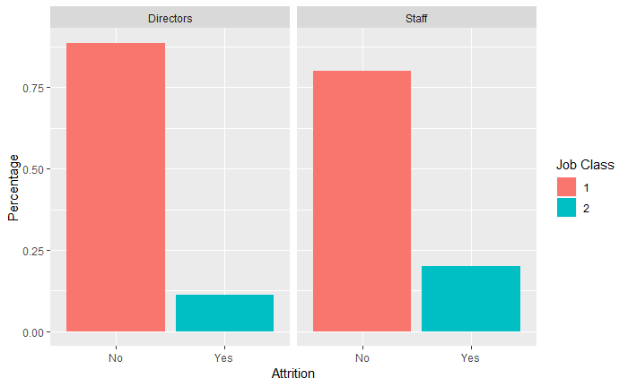

```r
ggplot(hr_data,aes(x=Attrition,group=jobclass))+
  geom_bar(stat="count",aes(y=..prop..,fill=factor(..x..))) +
  labs(y="Percentage", fill = "Job Class") +
  facet_wrap(~jobclass)
```

As expected the staff of the company tend to leave more than the directors of the organization.

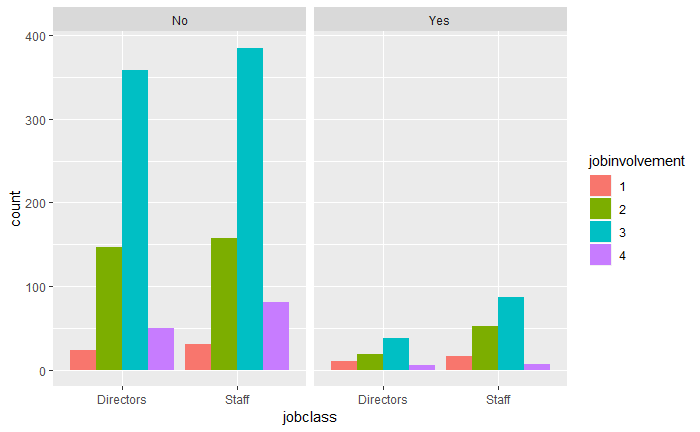

```r
ggplot(hr_data, aes(jobclass, fill = jobinvolvement)) + geom_bar(stat= "count", position =  position_dodge()) + facet_wrap(~Attrition)
```

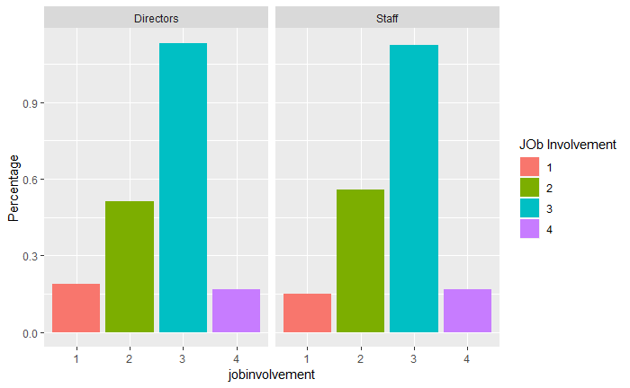

```r
ggplot(hr_data,aes(x=jobinvolvement,group=Attrition))+
  geom_bar(stat="count",aes(y=..prop..,fill=factor(..x..))) +
  labs(y="Percentage", fill = "JOb Involvement") +
  facet_wrap(~jobclass)
```

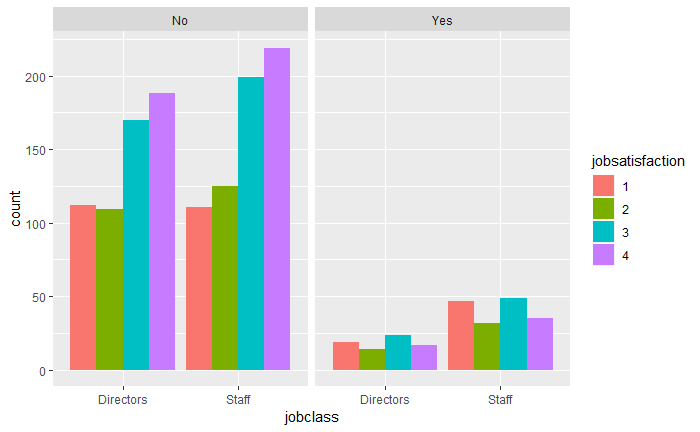

```r
ggplot(hr_data, aes(jobclass, fill = jobsatisfaction)) + geom_bar(stat= "count", position =  position_dodge()) + facet_wrap(~Attrition)
```

```r
#Income level
hr_data$Incomelevel <- as.factor(ifelse (hr_data$MonthlyIncome < ave(hr_data$MonthlyIncome), "Low", "High"))
table(hr_data$Incomelevel, hr_data$Attrition)
```

```
        No Yes
  High 441  52
  Low  792 185
```

# Years without employee change

```r
hr_data$Yearswithoutchange <- hr_data$Yearsincurrentrole - hr_data$Yearssincelastpromotion
str(hr_data$Yearswithoutchange)
```

```
 num [1:1470] 4 6 0 4 0 4 0 0 6 0 ...
```

# Divide the data into training and test dataset.

Data Preprocessing Convert characters to factors and remove

```r
hr_dataclean <- hr_data
hr_dataclean = hr_dataclean[,!(names(hr_dataclean) %in% c('Marital Status','Job Role','Attrition (Yes/No)','Marital Status','Education Field','Business Travel','Job Involvement','Job Satisfaction','Job Level','Hourly Rate (USD)','Daily Rate (USD)','Monthly Rate (USD)','Monthly Income (USD)','Salary Hike (%)','Stock Option Level','Over Time','No. of Companies Worked','Total Working Years','Years At Company','Years In Current Role','Years Since Last Promotion','Years With Curr Manager','Environment Satisfaction','Training Times Last Year','Work Life Balance','Performance Rating','Relationship Satisfaction','Distance From Home (kms)'))]
str(hr_dataclean)
```

```
Classes ‘tbl_df’, ‘tbl’ and 'data.frame':   1470 obs. of  37 variables:
 $ Department              : chr  "Sales" "Research & Development" "Research & Development" "Research & Development" ...
 $ Gender                  : chr  "Female" "Male" "Male" "Female" ...
 $ Age                     : num  41 49 37 33 27 32 59 30 38 36 ...
 $ Education               : chr  "College" "Below College" "College" "Master" ...
 $ Attrition               : chr  "Yes" "No" "Yes" "No" ...
 $ MaritalStatus           : chr  "Single" "Married" "Single" "Married" ...
 $ BusinessTravel          : chr  "Travel_Rarely" "Travel_Frequently" "Travel_Rarely" "Travel_Frequently" ...
 $ JobRole                 : chr  "Sales Executive" "Research Scientist" "Laboratory Technician" "Research Scientist" ...
 $ DistancefromHome        : num  1 8 2 3 2 2 3 24 23 27 ...
 $ DailyRate               : num  1102 279 1373 1392 591 ...
 $ HourlyRate              : num  94 61 92 56 40 79 81 67 44 94 ...
 $ MonthlyRate             : num  19479 24907 2396 23159 16632 ...
 $ MonthlyIncome           : num  5993 5130 2090 2909 3468 ...
 $ totalRate               : num  20675 25247 3861 24607 17263 ...
```

[output cut: 23 more lines]

```r
hr_dataclean$Department <- as.factor(hr_dataclean$Department)
hr_dataclean$Education <- as.factor(hr_dataclean$Education)
hr_dataclean$Attrition <- as.factor(hr_dataclean$Attrition)
hr_dataclean$MaritalStatus <- as.factor(hr_dataclean$MaritalStatus)
hr_dataclean$BusinessTravel <- as.factor(hr_dataclean$BusinessTravel)
hr_dataclean$JobRole <- as.factor(hr_dataclean$JobRole)
hr_dataclean$educationfield <- as.factor(hr_dataclean$educationfield)
hr_dataclean$jobsatisfaction <- as.factor(hr_dataclean$jobsatisfaction)
hr_dataclean$jobinvolvement <- as.factor(hr_dataclean$jobinvolvement)
hr_dataclean$relationshipsatisfaction <- as.factor(hr_dataclean$relationshipsatisfaction)
hr_dataclean$worklifebalance <- as.factor(hr_dataclean$worklifebalance)
hr_dataclean$environmentsatisfaction <- as.factor(hr_dataclean$environmentsatisfaction)
hr_dataclean$overtime <- as.factor(hr_dataclean$overtime)
hr_dataclean$performancerating <- as.factor(hr_dataclean$performancerating)
hr_dataclean$jobclass <- as.factor(hr_dataclean$jobclass)
hr_dataclean$Gender <- as.factor(hr_dataclean$Gender)
str(hr_dataclean)
```

```
Classes ‘tbl_df’, ‘tbl’ and 'data.frame':   1470 obs. of  37 variables:
 $ Department              : Factor w/ 3 levels "Human Resources",..: 3 2 2 2 2 2 2 2 2 2 ...
 $ Gender                  : Factor w/ 2 levels "Female","Male": 1 2 2 1 2 2 1 2 2 2 ...
 $ Age                     : num  41 49 37 33 27 32 59 30 38 36 ...
 $ Education               : Factor w/ 5 levels "Bachelor","Below College",..: 3 2 3 5 2 3 1 2 1 1 ...
 $ Attrition               : Factor w/ 2 levels "No","Yes": 2 1 2 1 1 1 1 1 1 1 ...
 $ MaritalStatus           : Factor w/ 3 levels "Divorced","Married",..: 3 2 3 2 2 3 2 1 3 2 ...
 $ BusinessTravel          : Factor w/ 3 levels "Non-Travel","Travel_Frequently",..: 3 2 3 2 3 2 3 3 2 3 ...
 $ JobRole                 : Factor w/ 9 levels "Healthcare Representative",..: 8 7 3 7 3 3 3 3 5 1 ...
 $ DistancefromHome        : num  1 8 2 3 2 2 3 24 23 27 ...
 $ DailyRate               : num  1102 279 1373 1392 591 ...
 $ HourlyRate              : num  94 61 92 56 40 79 81 67 44 94 ...
 $ MonthlyRate             : num  19479 24907 2396 23159 16632 ...
 $ MonthlyIncome           : num  5993 5130 2090 2909 3468 ...
 $ totalRate               : num  20675 25247 3861 24607 17263 ...
```

[output cut: 23 more lines]

```r
#Divide the data into training and test dataset.
trainIndex <- createDataPartition(hr_dataclean$Attrition, p = 0.7, list = FALSE)
trainData <- hr_dataclean[trainIndex,]
testData  <- hr_dataclean[-trainIndex,]
```

# uSING THE SMOTE METHOD TO balance classification

The data(Attrition is unbalanced)

```r
prop.table(table(hr_data$Attrition))*100
```

```
      No      Yes
83.87755 16.12245
```

```r
trainData <- as.data.frame(trainData)
smote_train <- SMOTE(Attrition ~ .,data=trainData)
balanced_data =  prop.table(table(smote_train$Attrition))*100
cat("Balanced proportions is"); print(balanced_data, row.names=FALSE)
```

```
Balanced proportions is
      No      Yes
57.14286 42.85714
```

The unbalanced data showed that 84% stayed as compared to 16% who left the organization, however doing a binary classification has balanced the data set and now we have 57% who did not leave as compared to 43% who left.

We will proceed to feature selection using the Boruta package. We can also use the lime package, but in this notebook, we will use the Boruta package.

# Feature selection using Boruta

```r
set.seed(1337)
boruta_output=Boruta(Attrition~.,data=smote_train,doTrace=2)
```

[output not shown]

[output cut: 52 more lines]

[output not shown]

```r
print(boruta_output)
```

```
Boruta performed 99 iterations in 2.239246 mins.
 34 attributes confirmed important: Age, AgeGroup, BusinessTravel, DailyRate,
Department and 29 more;
 No attributes deemed unimportant.
 2 tentative attributes left: Gender, performancerating;
```

# Tentative feature

Print out the new important features and display the boruta plot

```r
boruta_train <- TentativeRoughFix(boruta_output)
cat("New important features", getSelectedAttributes(boruta_train), sep = "\n")
```

```
New important features
Department
Gender
Age
Education
MaritalStatus
BusinessTravel
JobRole
DistancefromHome
DailyRate
HourlyRate
MonthlyRate
MonthlyIncome
totalRate
Numcompworked
Yearsatcompany
Yearsincurrentrole
Yearswithcurrmanager
Yearssincelastpromotion
totalworkingyears
trainingtimeslastyear
stockoptionlevel
salaryhike
educationfield
jobsatisfaction
jobinvolvement
relationshipsatisfaction
worklifebalance
environmentsatisfaction
overtime
performancerating
AgeGroup
OverallSatisfaction
OverallSatisfactionlevel
jobclass
Incomelevel
Yearswithoutchange
```

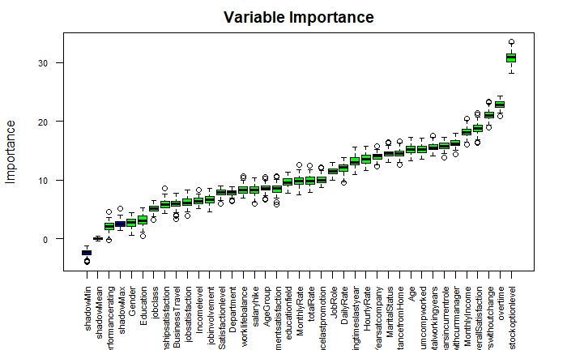

```r
plot(boruta_train, cex.axis=.7, las=2, xlab=" ", main="Variable Importance")
```

Display the boruta output statistics

```r
boruta_stat <- attStats(boruta_output)
print(boruta_stat)
```

|  | meanImp | medianImp | minImp | maxImp | normHits | decision |
| --- | --- | --- | --- | --- | --- | --- |
| Department | 7.011178 | 7.010052 | 6.0096557 | 8.457633 | 1.0000000 | Confirmed |
| Gender | 2.807263 | 2.809667 | 0.5451674 | 4.778005 | 0.5959596 | Tentative |
| Age | 15.424839 | 15.420711 | 13.7063331 | 16.999161 | 1.0000000 | Confirmed |
| Education | 4.862251 | 4.906429 | 2.9057531 | 7.011693 | 0.9898990 | Confirmed |
| MaritalStatus | 16.265671 | 16.340549 | 14.8640613 | 17.704566 | 1.0000000 | Confirmed |
| BusinessTravel | 5.740759 | 5.835469 | 3.5396304 | 7.945531 | 0.9898990 | Confirmed |
| JobRole | 11.793233 | 11.827406 | 10.0492453 | 13.650116 | 1.0000000 | Confirmed |
| DistancefromHome | 14.785805 | 14.805839 | 13.1300867 | 16.318103 | 1.0000000 | Confirmed |
| DailyRate | 16.758667 | 16.817222 | 14.8906056 | 18.323751 | 1.0000000 | Confirmed |
| HourlyRate | 13.893942 | 13.757864 | 11.3258225 | 16.459793 | 1.0000000 | Confirmed |

[output cut: 25 more lines]